# Investigate a Dataset - IMDB Movies Dataset

```python
# import libraries and packages

import numpy as np
import pandas as pd
import matplotlib.pyplot as plt
%matplotlib inline
import seaborn as sns
sns.set_style('darkgrid')
```

### Introduction

#### Dataset Description

The data is gotten from Udacity, it is about Hollywood movies in different genres from 1960 to 2015

It has 10866 rows and 21 columns

#### Columns

- id
- imdb_id
- popularity
- budget
- revenue
- original_title
- cast
- homepage

#### Questions for Analysis

- What kind of movies had highest budget and revenue?
- Is duration affect the popularity of movies?
- Who is the most famous director?
- What is the most famous production company?
- How many movies are Documentary?

### Data Wrangling

Gather

```python
df = pd.read_csv("C:/Users\( ^_^ )/OneDrive/Desktop/tmdb-movies.csv")
```

Assess

```python
df.head()
```

|  | id | imdb_id | popularity | budget | revenue | original_title | cast | homepage | director | tagline | ... | overview | runtime | genres | production_companies | release_date | vote_count | vote_average | release_year | budget_adj | revenue_adj |
| --- | --- | --- | --- | --- | --- | --- | --- | --- | --- | --- | --- | --- | --- | --- | --- | --- | --- | --- | --- | --- | --- |
| 0 | 135397 | tt0369610 | 32.985763 | 150000000 | 1513528810 | Jurassic World | Chris Pratt\|Bryce Dallas Howard\|Irrfan Khan\|Vi... | http://www.jurassicworld.com/ | Colin Trevorrow | The park is open. | ... | Twenty-two years after the events of Jurassic ... | 124 | Action\|Adventure\|Science Fiction\|Thriller | Universal Studios\|Amblin Entertainment\|Legenda... | 6/9/15 | 5562 | 6.5 | 2015 | 1.379999e+08 | 1.392446e+09 |
| 1 | 76341 | tt1392190 | 28.419936 | 150000000 | 378436354 | Mad Max: Fury Road | Tom Hardy\|Charlize Theron\|Hugh Keays-Byrne\|Nic... | http://www.madmaxmovie.com/ | George Miller | What a Lovely Day. | ... | An apocalyptic story set in the furthest reach... | 120 | Action\|Adventure\|Science Fiction\|Thriller | Village Roadshow Pictures\|Kennedy Miller Produ... | 5/13/15 | 6185 | 7.1 | 2015 | 1.379999e+08 | 3.481613e+08 |
| 2 | 262500 | tt2908446 | 13.112507 | 110000000 | 295238201 | Insurgent | Shailene Woodley\|Theo James\|Kate Winslet\|Ansel... | http://www.thedivergentseries.movie/#insurgent | Robert Schwentke | One Choice Can Destroy You | ... | Beatrice Prior must confront her inner demons ... | 119 | Adventure\|Science Fiction\|Thriller | Summit Entertainment\|Mandeville Films\|Red Wago... | 3/18/15 | 2480 | 6.3 | 2015 | 1.012000e+08 | 2.716190e+08 |
| 3 | 140607 | tt2488496 | 11.173104 | 200000000 | 2068178225 | Star Wars: The Force Awakens | Harrison Ford\|Mark Hamill\|Carrie Fisher\|Adam D... | http://www.starwars.com/films/star-wars-episod... | J.J. Abrams | Every generation has a story. | ... | Thirty years after defeating the Galactic Empi... | 136 | Action\|Adventure\|Science Fiction\|Fantasy | Lucasfilm\|Truenorth Productions\|Bad Robot | 12/15/15 | 5292 | 7.5 | 2015 | 1.839999e+08 | 1.902723e+09 |
| 4 | 168259 | tt2820852 | 9.335014 | 190000000 | 1506249360 | Furious 7 | Vin Diesel\|Paul Walker\|Jason Statham\|Michelle ... | http://www.furious7.com/ | James Wan | Vengeance Hits Home | ... | Deckard Shaw seeks revenge against Dominic Tor... | 137 | Action\|Crime\|Thriller | Universal Pictures\|Original Film\|Media Rights ... | 4/1/15 | 2947 | 7.3 | 2015 | 1.747999e+08 | 1.385749e+09 |

5 rows × 21 columns

```python
df.info
```

[output not shown]

[output cut: 103 more lines]

```python
df.describe(include='all')
```

|  | id | imdb_id | popularity | budget | revenue | original_title | cast | homepage | director | tagline | ... | overview | runtime | genres | production_companies | release_date | vote_count | vote_average | release_year | budget_adj | revenue_adj |
| --- | --- | --- | --- | --- | --- | --- | --- | --- | --- | --- | --- | --- | --- | --- | --- | --- | --- | --- | --- | --- | --- |
| count | 10866.000000 | 10856 | 10866.000000 | 1.086600e+04 | 1.086600e+04 | 10866 | 10790 | 2936 | 10822 | 8042 | ... | 10862 | 10866.000000 | 10843 | 9836 | 10866 | 10866.000000 | 10866.000000 | 10866.000000 | 1.086600e+04 | 1.086600e+04 |
| unique | NaN | 10855 | NaN | NaN | NaN | 10571 | 10719 | 2896 | 5067 | 7997 | ... | 10847 | NaN | 2039 | 7445 | 5909 | NaN | NaN | NaN | NaN | NaN |
| top | NaN | tt0411951 | NaN | NaN | NaN | Hamlet | Louis C.K. | http://www.thehungergames.movie/ | Woody Allen | Based on a true story. | ... | No overview found. | NaN | Comedy | Paramount Pictures | 1/1/09 | NaN | NaN | NaN | NaN | NaN |
| freq | NaN | 2 | NaN | NaN | NaN | 4 | 6 | 4 | 45 | 5 | ... | 13 | NaN | 712 | 156 | 28 | NaN | NaN | NaN | NaN | NaN |
| mean | 66064.177434 | NaN | 0.646441 | 1.462570e+07 | 3.982332e+07 | NaN | NaN | NaN | NaN | NaN | ... | NaN | 102.070863 | NaN | NaN | NaN | 217.389748 | 5.974922 | 2001.322658 | 1.755104e+07 | 5.136436e+07 |
| std | 92130.136561 | NaN | 1.000185 | 3.091321e+07 | 1.170035e+08 | NaN | NaN | NaN | NaN | NaN | ... | NaN | 31.381405 | NaN | NaN | NaN | 575.619058 | 0.935142 | 12.812941 | 3.430616e+07 | 1.446325e+08 |
| min | 5.000000 | NaN | 0.000065 | 0.000000e+00 | 0.000000e+00 | NaN | NaN | NaN | NaN | NaN | ... | NaN | 0.000000 | NaN | NaN | NaN | 10.000000 | 1.500000 | 1960.000000 | 0.000000e+00 | 0.000000e+00 |
| 25% | 10596.250000 | NaN | 0.207583 | 0.000000e+00 | 0.000000e+00 | NaN | NaN | NaN | NaN | NaN | ... | NaN | 90.000000 | NaN | NaN | NaN | 17.000000 | 5.400000 | 1995.000000 | 0.000000e+00 | 0.000000e+00 |
| 50% | 20669.000000 | NaN | 0.383856 | 0.000000e+00 | 0.000000e+00 | NaN | NaN | NaN | NaN | NaN | ... | NaN | 99.000000 | NaN | NaN | NaN | 38.000000 | 6.000000 | 2006.000000 | 0.000000e+00 | 0.000000e+00 |
| 75% | 75610.000000 | NaN | 0.713817 | 1.500000e+07 | 2.400000e+07 | NaN | NaN | NaN | NaN | NaN | ... | NaN | 111.000000 | NaN | NaN | NaN | 145.750000 | 6.600000 | 2011.000000 | 2.085325e+07 | 3.369710e+07 |
| max | 417859.000000 | NaN | 32.985763 | 4.250000e+08 | 2.781506e+09 | NaN | NaN | NaN | NaN | NaN | ... | NaN | 900.000000 | NaN | NaN | NaN | 9767.000000 | 9.200000 | 2015.000000 | 4.250000e+08 | 2.827124e+09 |

11 rows × 21 columns

```python
df.isnull().sum()
```

```
id                         0
imdb_id                   10
popularity                 0
budget                     0
revenue                    0
original_title             0
cast                      76
homepage                7930
director                  44
tagline                 2824
keywords                1493
overview                   4
runtime                    0
genres                    23
production_companies    1030
release_date               0
vote_count                 0
vote_average               0
release_year               0
budget_adj                 0
revenue_adj                0
dtype: int64
```

```python
df.duplicated().sum()
```

```
1
```

Cleaning

```python
df = df.drop_duplicates()
```

```python
#There are some columns are useless during analysis, these include; homepage, cast, tagline, keywords and overview these were obtained during scraping process
#other column to be dropped is release_date so we can remain with release year

df = df.drop(columns=['cast', 'homepage', 'tagline', 'overview', 'release_date','keywords'])

df.columns
```

```
Index(['id', 'imdb_id', 'popularity', 'budget', 'revenue', 'original_title',
       'director', 'runtime', 'genres', 'production_companies', 'vote_count',
       'vote_average', 'release_year', 'budget_adj', 'revenue_adj'],
      dtype='object')
```

### Exploratory Data Analysis

##### What kind of movies had highest budget and revenue?

```python
#Creating a function that return maximum value for certain column

def Maximum_Value(column):
    return df[df[column]==df[column].max()]


#starting with maximum budget

Maximum_Value('budget')
```

|  | id | imdb_id | popularity | budget | revenue | original_title | director | runtime | genres | production_companies | vote_count | vote_average | release_year | budget_adj | revenue_adj |
| --- | --- | --- | --- | --- | --- | --- | --- | --- | --- | --- | --- | --- | --- | --- | --- |
| 2244 | 46528 | tt1032751 | 0.25054 | 425000000 | 11087569 | The Warrior's Way | Sngmoo Lee | 100 | Adventure\|Fantasy\|Action\|Western\|Thriller | Boram Entertainment Inc. | 74 | 6.4 | 2010 | 425000000.0 | 11087569.0 |

```python
#For maximum revenue

Maximum_Value('revenue')
```

|  | id | imdb_id | popularity | budget | revenue | original_title | director | runtime | genres | production_companies | vote_count | vote_average | release_year | budget_adj | revenue_adj |
| --- | --- | --- | --- | --- | --- | --- | --- | --- | --- | --- | --- | --- | --- | --- | --- |
| 1386 | 19995 | tt0499549 | 9.432768 | 237000000 | 2781505847 | Avatar | James Cameron | 162 | Action\|Adventure\|Fantasy\|Science Fiction | Ingenious Film Partners\|Twentieth Century Fox ... | 8458 | 7.1 | 2009 | 2.408869e+08 | 2.827124e+09 |

##### Is duration affect the popularity of movies?

```python
#For maximum runtime we can use our function

Maximum_Value('runtime')
```

|  | id | imdb_id | popularity | budget | revenue | original_title | director | runtime | genres | production_companies | vote_count | vote_average | release_year | budget_adj | revenue_adj |
| --- | --- | --- | --- | --- | --- | --- | --- | --- | --- | --- | --- | --- | --- | --- | --- |
| 3894 | 125336 | tt2044056 | 0.006925 | 0 | 0 | The Story of Film: An Odyssey | Mark Cousins | 900 | Documentary | NaN | 14 | 9.2 | 2011 | 0.0 | 0.0 |

```python
#But for minimum runtime we cant use the function since we defined only for maximum outputs

df[df['runtime']==df['runtime'].min()]
```

|  | id | imdb_id | popularity | budget | revenue | original_title | director | runtime | genres | production_companies | vote_count | vote_average | release_year | budget_adj | revenue_adj |
| --- | --- | --- | --- | --- | --- | --- | --- | --- | --- | --- | --- | --- | --- | --- | --- |
| 92 | 370687 | tt3608646 | 1.876037 | 0 | 0 | Mythica: The Necromancer | A. Todd Smith | 0 | Fantasy\|Action\|Adventure | Arrowstorm Entertainment\|Camera 40 Productions... | 11 | 5.4 | 2015 | 0.000000e+00 | 0.0 |
| 334 | 361931 | tt5065822 | 0.357654 | 0 | 0 | Ronaldo | Anthony Wonke | 0 | Documentary | On The Corner Films\|We Came, We Saw, We Conque... | 80 | 6.5 | 2015 | 0.000000e+00 | 0.0 |
| 410 | 339342 | tt2948712 | 0.097514 | 0 | 0 | Anarchy Parlor | Kenny Gage\|Devon Downs | 0 | Horror | NaN | 15 | 5.6 | 2015 | 0.000000e+00 | 0.0 |
| 445 | 353345 | tt3800796 | 0.218528 | 0 | 0 | The Exorcism of Molly Hartley | Steven R. Monroe | 0 | Horror | WT Canada Productions | 52 | 5.0 | 2015 | 0.000000e+00 | 0.0 |
| 486 | 333653 | tt4058368 | 0.176744 | 0 | 0 | If There Be Thorns | Nancy Savoca | 0 | TV Movie\|Drama | A+E Studios\|Jane Startz Productions | 11 | 5.4 | 2015 | 0.000000e+00 | 0.0 |
| 595 | 341051 | tt2914740 | 0.028725 | 0 | 0 | Deep Dark | Michael Medaglia | 0 | Horror | NaN | 11 | 4.6 | 2015 | 0.000000e+00 | 0.0 |
| 616 | 325843 | tt4333210 | 0.026797 | 0 | 0 | The Outfield | Michael Goldfine | 0 | Drama\|Comedy | NaN | 20 | 6.6 | 2015 | 0.000000e+00 | 0.0 |
| 1241 | 296370 | tt3024964 | 0.135376 | 0 | 0 | Dance-Off | NaN | 0 | Romance\|Music\|Comedy | NaN | 18 | 5.7 | 2014 | 0.000000e+00 | 0.0 |
| 1289 | 286372 | tt1791681 | 0.037459 | 3250000 | 0 | Treehouse | Michael G. Bartlett | 0 | Thriller\|Horror\|Mystery | Tiberius Film | 16 | 3.4 | 2014 | 2.993546e+06 | 0.0 |
| 1293 | 286256 | tt3134058 | 0.036904 | 0 | 0 | Tim Maia | Mauro Lima | 0 | Documentary\|Drama\|Music | Globo Filmes | 14 | 6.0 | 2014 | 0.000000e+00 | 0.0 |
| 1849 | 18247 | tt1212986 | 0.120350 | 0 | 0 | Spectacular! | Robert Iscove | 0 | Drama\|Music | NaN | 13 | 5.2 | 2009 | 0.000000e+00 | 0.0 |
| 2315 | 48373 | tt1274296 | 0.171615 | 0 | 0 | Listen to Your Heart | NaN | 0 | Drama\|Music\|Romance | NaN | 29 | 7.3 | 2010 | 0.000000e+00 | 0.0 |
| 2370 | 127717 | tt1525359 | 0.081892 | 0 | 0 | Freshman Father | Michael Scott | 0 | NaN | NaN | 12 | 5.8 | 2010 | 0.000000e+00 | 0.0 |
| 3329 | 20414 | tt1077026 | 0.082898 | 0 | 0 | Grande, grosso e Verdone | Carlo Verdone | 0 | Family | Filmauro | 35 | 5.3 | 2008 | 0.000000e+00 | 0.0 |
| 3794 | 58253 | tt1588335 | 0.183134 | 0 | 0 | Toi, moi, les autres | Audrey Estrougo | 0 | Music\|Romance | NaN | 17 | 5.2 | 2011 | 0.000000e+00 | 0.0 |
| 3857 | 289097 | tt1288636 | 0.095583 | 0 | 0 | Cell 213 | Stephen Kay | 0 | Horror | Access Motion Pictures | 13 | 5.2 | 2011 | 0.000000e+00 | 0.0 |
| 3884 | 105885 | tt1754944 | 0.045198 | 0 | 0 | eCupid | J.C. Calciano | 0 | Romance | NaN | 12 | 4.6 | 2011 | 0.000000e+00 | 0.0 |
| 4063 | 28004 | tt0359639 | 0.371510 | 6000000 | 0 | Madea's Family Reunion | Tyler Perry | 0 | Comedy | NaN | 49 | 5.9 | 2002 | 7.273568e+06 | 0.0 |
| 4138 | 44266 | tt0242953 | 0.035895 | 0 | 0 | A Time for Dancing | Peter Gilbert | 0 | Drama\|Music | NaN | 14 | 7.5 | 2002 | 0.000000e+00 | 0.0 |
| 4829 | 110490 | tt1910605 | 0.140016 | 0 | 0 | Rags | Bille Woodruff | 0 | TV Movie\|Comedy\|Drama | NaN | 24 | 5.7 | 2012 | 0.000000e+00 | 0.0 |
| 4944 | 158150 | tt2395247 | 0.026459 | 0 | 0 | How to Fall in Love | Mark Griffiths | 0 | Comedy\|Romance\|TV Movie | Annuit Coeptis Entertainment Inc.\|Annuit Coept... | 11 | 4.7 | 2012 | 0.000000e+00 | 0.0 |
| 5216 | 28003 | tt0427481 | 0.073665 | 0 | 0 | Madea's Class Reunion | Tyler Perry | 0 | Comedy\|Music | NaN | 12 | 6.9 | 2003 | 0.000000e+00 | 0.0 |
| 5695 | 224815 | tt2881698 | 0.417739 | 0 | 0 | Skinwalker Ranch | Devin McGinn | 0 | Thriller\|Horror\|Science Fiction | DeepStudios | 27 | 4.3 | 2013 | 0.000000e+00 | 0.0 |
| 5920 | 248842 | tt2364006 | 0.165765 | 0 | 0 | The Food Guide to Love | Dominic Harari\|Teresa Pelegri | 0 | Romance\|Comedy | Haut et Court\|Parallel Film Productions\|Fox In... | 12 | 5.6 | 2013 | 0.000000e+00 | 0.0 |
| 5938 | 191562 | tt2436516 | 0.147188 | 0 | 0 | Go Goa Gone | Krishna D.K.\|Raj Nidimoru | 0 | Comedy\|Horror | Eros International | 16 | 5.3 | 2013 | 0.000000e+00 | 0.0 |
| 5992 | 173847 | tt2343371 | 0.096455 | 0 | 0 | Amiche da morire | Giorgia Farina | 0 | Romance\|Crime\|Comedy | NaN | 30 | 5.5 | 2013 | 0.000000e+00 | 0.0 |
| 6040 | 202604 | tt3043194 | 0.011798 | 0 | 0 | The Vatican Exorcisms | Joe Marino | 0 | Horror\|Documentary\|Mystery | NaN | 10 | 4.7 | 2013 | 0.000000e+00 | 0.0 |
| 6383 | 26985 | tt0405615 | 0.371630 | 2000000 | 0 | The 12 Dogs of Christmas | Kieth Merrill | 0 | Drama\|Family | NaN | 11 | 4.7 | 2005 | 2.233127e+06 | 0.0 |
| 6552 | 13739 | tt0448245 | 0.006440 | 0 | 0 | Quatre étoiles | Christian Vincent | 0 | Comedy | NaN | 15 | 5.9 | 2005 | 0.000000e+00 | 0.0 |
| 6934 | 13713 | tt0477988 | 0.071872 | 0 | 0 | Jean-Philippe | Laurent Tuel | 0 | Comedy | Fidélité Productions\|StudioCanal\|TF1 Films P... | 26 | 5.6 | 2006 | 0.000000e+00 | 0.0 |
| 8874 | 46406 | tt0248185 | 0.069903 | 0 | 0 | Mission Kashmir | Vidhu Vinod Chopra | 0 | Action\|Drama\|Foreign | NaN | 10 | 5.7 | 2000 | 0.000000e+00 | 0.0 |

```python
#Here we want to get movies with lowest runtime but highest popularity

low_runtime=df[df['runtime']==df['runtime'].min()]

#highest popularity from lowest runtime
low_runtime[low_runtime['popularity']==low_runtime['popularity'].max()]
```

|  | id | imdb_id | popularity | budget | revenue | original_title | director | runtime | genres | production_companies | vote_count | vote_average | release_year | budget_adj | revenue_adj |
| --- | --- | --- | --- | --- | --- | --- | --- | --- | --- | --- | --- | --- | --- | --- | --- |
| 92 | 370687 | tt3608646 | 1.876037 | 0 | 0 | Mythica: The Necromancer | A. Todd Smith | 0 | Fantasy\|Action\|Adventure | Arrowstorm Entertainment\|Camera 40 Productions... | 11 | 5.4 | 2015 | 0.0 | 0.0 |

```python
#for highest popularite we can use our function

Maximum_Value('popularity')
```

|  | id | imdb_id | popularity | budget | revenue | original_title | director | runtime | genres | production_companies | vote_count | vote_average | release_year | budget_adj | revenue_adj |
| --- | --- | --- | --- | --- | --- | --- | --- | --- | --- | --- | --- | --- | --- | --- | --- |
| 0 | 135397 | tt0369610 | 32.985763 | 150000000 | 1513528810 | Jurassic World | Colin Trevorrow | 124 | Action\|Adventure\|Science Fiction\|Thriller | Universal Studios\|Amblin Entertainment\|Legenda... | 5562 | 6.5 | 2015 | 1.379999e+08 | 1.392446e+09 |

##### Who is the most famous director?

```python
#for highest popularite we can use our function

Maximum_Value('popularity')
```

|  | id | imdb_id | popularity | budget | revenue | original_title | director | runtime | genres | production_companies | vote_count | vote_average | release_year | budget_adj | revenue_adj |
| --- | --- | --- | --- | --- | --- | --- | --- | --- | --- | --- | --- | --- | --- | --- | --- |
| 0 | 135397 | tt0369610 | 32.985763 | 150000000 | 1513528810 | Jurassic World | Colin Trevorrow | 124 | Action\|Adventure\|Science Fiction\|Thriller | Universal Studios\|Amblin Entertainment\|Legenda... | 5562 | 6.5 | 2015 | 1.379999e+08 | 1.392446e+09 |

```python
#Here we want to count each appearance of directors in ascending order

df['director'].value_counts().sort_values(ascending=True)
```

```
Juno John Lee        1
Jeremy M. Inman      1
Brin Hill            1
Roy Wilson           1
Michael Goguen       1
                    ..
Ridley Scott        23
Martin Scorsese     29
Steven Spielberg    29
Clint Eastwood      34
Woody Allen         45
Name: director, Length: 5067, dtype: int64
```

We can say that the most famous director is Woody Allen depending on highest number movies appeared 45 times but considering single most popular movie director Colin Trevorrow can be the most famous since his movie Jurassic World have highest popularity score

##### What is the most famous production company?

```python
#for highest popularite we can use our function and we can extract the company produced the most popular movie

Maximum_Value('popularity')
```

|  | id | imdb_id | popularity | budget | revenue | original_title | director | runtime | genres | production_companies | vote_count | vote_average | release_year | budget_adj | revenue_adj |
| --- | --- | --- | --- | --- | --- | --- | --- | --- | --- | --- | --- | --- | --- | --- | --- |
| 0 | 135397 | tt0369610 | 32.985763 | 150000000 | 1513528810 | Jurassic World | Colin Trevorrow | 124 | Action\|Adventure\|Science Fiction\|Thriller | Universal Studios\|Amblin Entertainment\|Legenda... | 5562 | 6.5 | 2015 | 1.379999e+08 | 1.392446e+09 |

```python
#Here we want to count each appearance of production company in ascending order

df['production_companies'].value_counts().sort_values(ascending=True)
```

```
Electric Entertainment|Turner Network Television (TNT)|ApolloProScreen Filmproduktion              1
Patriot Pictures                                                                                   1
Sahamongkol Film                                                                                   1
Devon/Persky-Bright                                                                                1
Village Roadshow Pictures|DC Comics|Vertigo Entertainment|Lin Pictures|Warner Bros. Animation      1
                                                                                                ...
Metro-Goldwyn-Mayer (MGM)                                                                         72
Walt Disney Pictures                                                                              76
Warner Bros.                                                                                      84
Universal Pictures                                                                               133
Paramount Pictures                                                                               156
Name: production_companies, Length: 7445, dtype: int64
```

We can say that the most famous production company is Paramount Pictures depending on highest number movies appeared 156 times but considering single most popular movie Universal Studios|Amblin Entertainment|Legenda can be the most famous company since his movie Jurassic World have highest popularity score

##### How many movies are Documentary?

```python
df['genres'].value_counts().Documentary
```

```
312
```

### Function

```python
def graph(a, b, dataframe, Title):
    plt.figure(figsize=(8,6))
    sns.boxplot(x= a, y= b, data=dataframe)
    plt.xticks(rotation=15)
    plt.title(Title);
```

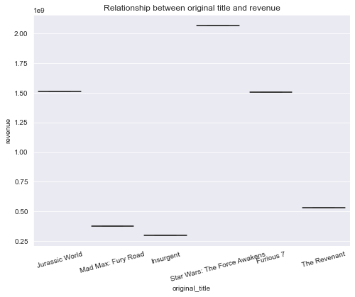

```python
graph(df['original_title'][0:6], df['revenue'][0:6], df, 'Relationship between original title and revenue')
```

From these first 6 movies we can say Star Wars: The Force AwAkens had highest revenue

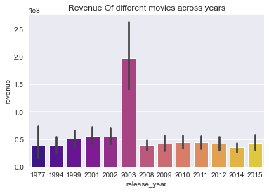

```python
sns.barplot(x =df['release_year'][0:5000], y =df['revenue'][0:5000], data = df,
            palette ='plasma')
plt.title('Revenue Of different movies across years')
```

We can see 2003 had highest revenue projected near 200,000,000 dollars

[output not shown]

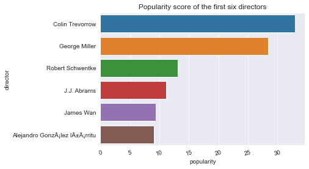

```python
sns.barplot(df.popularity, df['director'][0:6])
plt.xticks(rotation=15)
plt.title('Popularity score of the first six directors')
```

For the first 6 directors colin Treverrow is the most popular director with more than 30 popularity score followed by George Miller with popularity score less than 30 but greater than 25. Alejandro Gonzalez had lowest score less than 10 same as James Wan but a bit lower than him

### Limitation

- Most of data contain zero and null values

### Reference

- https://stackoverflow.com/questions/48590268/pandas-get-the-most-frequent-values-of-a-column
- https://www.codegrepper.com/code-examples/python/get+the+second+highest+value+pandas
- https://pandas.pydata.org/docs/